# Optimal Treatment Analysis

## Outcome Variable

**Outcome Variable:** ever_stunted

## Predictor Variables

**Intervention Variable:** nchldlt5

**Adjustment Set:**

- arm
- W_mage
- meducyrs
- feducyrs
- hhwealth_quart
- hfoodsec
- W_mhtcm
- W_nrooms
- W_parity
- impfloor
- impsan
- safeh20
- delta_W_mage
- delta_meducyrs
- delta_feducyrs
- delta_hhwealth_quart
- delta_hfoodsec
- delta_W_mhtcm
- delta_W_nrooms
- delta_W_parity
- delta_impfloor
- delta_impsan
- delta_safeh20

## Stratifying Variables

The analysis was stratified on these variable(s):

- agecat
- studyid
- country

## Data Summary

| agecat | studyid | country | nchldlt5 | ever_stunted | n_cell | n |
| --- | --- | --- | --- | --- | --- | --- |
| 0-24 months | ki1000108-IRC | INDIA | 1 | 0 | 35 | 291 |
| 0-24 months | ki1000108-IRC | INDIA | 1 | 1 | 54 | 291 |
| 0-24 months | ki1000108-IRC | INDIA | 2+ | 0 | 70 | 291 |
| 0-24 months | ki1000108-IRC | INDIA | 2+ | 1 | 132 | 291 |
| 0-24 months | ki1017093b-PROVIDE | BANGLADESH | 1 | 0 | 295 | 524 |
| 0-24 months | ki1017093b-PROVIDE | BANGLADESH | 1 | 1 | 217 | 524 |
| 0-24 months | ki1017093b-PROVIDE | BANGLADESH | 2+ | 0 | 9 | 524 |
| 0-24 months | ki1017093b-PROVIDE | BANGLADESH | 2+ | 1 | 3 | 524 |
| 0-24 months | ki1017093c-NIH-Crypto | BANGLADESH | 1 | 0 | 298 | 547 |
| 0-24 months | ki1017093c-NIH-Crypto | BANGLADESH | 1 | 1 | 243 | 547 |
| 0-24 months | ki1017093c-NIH-Crypto | BANGLADESH | 2+ | 0 | 4 | 547 |
| 0-24 months | ki1017093c-NIH-Crypto | BANGLADESH | 2+ | 1 | 2 | 547 |
| 0-24 months | ki1066203-TanzaniaChild2 | TANZANIA, UNITED REPUBLIC OF | 1 | 0 | 1077 | 1716 |
| 0-24 months | ki1066203-TanzaniaChild2 | TANZANIA, UNITED REPUBLIC OF | 1 | 1 | 560 | 1716 |
| 0-24 months | ki1066203-TanzaniaChild2 | TANZANIA, UNITED REPUBLIC OF | 2+ | 0 | 51 | 1716 |
| 0-24 months | ki1066203-TanzaniaChild2 | TANZANIA, UNITED REPUBLIC OF | 2+ | 1 | 28 | 1716 |
| 0-24 months | ki1112895-iLiNS-Zinc | BURKINA FASO | 1 | 0 | 711 | 1916 |
| 0-24 months | ki1112895-iLiNS-Zinc | BURKINA FASO | 1 | 1 | 362 | 1916 |
| 0-24 months | ki1112895-iLiNS-Zinc | BURKINA FASO | 2+ | 0 | 496 | 1916 |
| 0-24 months | ki1112895-iLiNS-Zinc | BURKINA FASO | 2+ | 1 | 347 | 1916 |
| 0-24 months | ki1148112-LCNI-5 | MALAWI | 1 | 0 | 145 | 454 |
| 0-24 months | ki1148112-LCNI-5 | MALAWI | 1 | 1 | 246 | 454 |
| 0-24 months | ki1148112-LCNI-5 | MALAWI | 2+ | 0 | 24 | 454 |
| 0-24 months | ki1148112-LCNI-5 | MALAWI | 2+ | 1 | 39 | 454 |
| 0-24 months | kiGH5241-JiVitA-3 | BANGLADESH | 1 | 0 | 8565 | 18054 |
| 0-24 months | kiGH5241-JiVitA-3 | BANGLADESH | 1 | 1 | 8849 | 18054 |
| 0-24 months | kiGH5241-JiVitA-3 | BANGLADESH | 2+ | 0 | 348 | 18054 |
| 0-24 months | kiGH5241-JiVitA-3 | BANGLADESH | 2+ | 1 | 292 | 18054 |
| 0-6 months | ki1000108-IRC | INDIA | 1 | 0 | 49 | 291 |
| 0-6 months | ki1000108-IRC | INDIA | 1 | 1 | 40 | 291 |
| 0-6 months | ki1000108-IRC | INDIA | 2+ | 0 | 118 | 291 |
| 0-6 months | ki1000108-IRC | INDIA | 2+ | 1 | 84 | 291 |
| 0-6 months | ki1017093b-PROVIDE | BANGLADESH | 1 | 0 | 384 | 524 |
| 0-6 months | ki1017093b-PROVIDE | BANGLADESH | 1 | 1 | 128 | 524 |
| 0-6 months | ki1017093b-PROVIDE | BANGLADESH | 2+ | 0 | 10 | 524 |
| 0-6 months | ki1017093b-PROVIDE | BANGLADESH | 2+ | 1 | 2 | 524 |
| 0-6 months | ki1017093c-NIH-Crypto | BANGLADESH | 1 | 0 | 386 | 547 |
| 0-6 months | ki1017093c-NIH-Crypto | BANGLADESH | 1 | 1 | 155 | 547 |
| 0-6 months | ki1017093c-NIH-Crypto | BANGLADESH | 2+ | 0 | 6 | 547 |
| 0-6 months | ki1017093c-NIH-Crypto | BANGLADESH | 2+ | 1 | 0 | 547 |
| 0-6 months | ki1066203-TanzaniaChild2 | TANZANIA, UNITED REPUBLIC OF | 1 | 0 | 1311 | 1716 |
| 0-6 months | ki1066203-TanzaniaChild2 | TANZANIA, UNITED REPUBLIC OF | 1 | 1 | 326 | 1716 |
| 0-6 months | ki1066203-TanzaniaChild2 | TANZANIA, UNITED REPUBLIC OF | 2+ | 0 | 66 | 1716 |
| 0-6 months | ki1066203-TanzaniaChild2 | TANZANIA, UNITED REPUBLIC OF | 2+ | 1 | 13 | 1716 |
| 0-6 months | ki1148112-LCNI-5 | MALAWI | 1 | 0 | 81 | 145 |
| 0-6 months | ki1148112-LCNI-5 | MALAWI | 1 | 1 | 41 | 145 |
| 0-6 months | ki1148112-LCNI-5 | MALAWI | 2+ | 0 | 13 | 145 |
| 0-6 months | ki1148112-LCNI-5 | MALAWI | 2+ | 1 | 10 | 145 |
| 0-6 months | kiGH5241-JiVitA-3 | BANGLADESH | 1 | 0 | 9822 | 18002 |
| 0-6 months | kiGH5241-JiVitA-3 | BANGLADESH | 1 | 1 | 7541 | 18002 |
| 0-6 months | kiGH5241-JiVitA-3 | BANGLADESH | 2+ | 0 | 413 | 18002 |
| 0-6 months | kiGH5241-JiVitA-3 | BANGLADESH | 2+ | 1 | 226 | 18002 |
| 6-24 months | ki1000108-IRC | INDIA | 1 | 0 | 35 | 167 |
| 6-24 months | ki1000108-IRC | INDIA | 1 | 1 | 14 | 167 |
| 6-24 months | ki1000108-IRC | INDIA | 2+ | 0 | 70 | 167 |
| 6-24 months | ki1000108-IRC | INDIA | 2+ | 1 | 48 | 167 |
| 6-24 months | ki1017093b-PROVIDE | BANGLADESH | 1 | 0 | 238 | 335 |
| 6-24 months | ki1017093b-PROVIDE | BANGLADESH | 1 | 1 | 89 | 335 |
| 6-24 months | ki1017093b-PROVIDE | BANGLADESH | 2+ | 0 | 7 | 335 |
| 6-24 months | ki1017093b-PROVIDE | BANGLADESH | 2+ | 1 | 1 | 335 |
| 6-24 months | ki1017093c-NIH-Crypto | BANGLADESH | 1 | 0 | 280 | 373 |
| 6-24 months | ki1017093c-NIH-Crypto | BANGLADESH | 1 | 1 | 88 | 373 |
| 6-24 months | ki1017093c-NIH-Crypto | BANGLADESH | 2+ | 0 | 3 | 373 |
| 6-24 months | ki1017093c-NIH-Crypto | BANGLADESH | 2+ | 1 | 2 | 373 |
| 6-24 months | ki1066203-TanzaniaChild2 | TANZANIA, UNITED REPUBLIC OF | 1 | 0 | 858 | 1145 |
| 6-24 months | ki1066203-TanzaniaChild2 | TANZANIA, UNITED REPUBLIC OF | 1 | 1 | 234 | 1145 |
| 6-24 months | ki1066203-TanzaniaChild2 | TANZANIA, UNITED REPUBLIC OF | 2+ | 0 | 38 | 1145 |
| 6-24 months | ki1066203-TanzaniaChild2 | TANZANIA, UNITED REPUBLIC OF | 2+ | 1 | 15 | 1145 |
| 6-24 months | ki1112895-iLiNS-Zinc | BURKINA FASO | 1 | 0 | 711 | 1916 |
| 6-24 months | ki1112895-iLiNS-Zinc | BURKINA FASO | 1 | 1 | 362 | 1916 |
| 6-24 months | ki1112895-iLiNS-Zinc | BURKINA FASO | 2+ | 0 | 496 | 1916 |
| 6-24 months | ki1112895-iLiNS-Zinc | BURKINA FASO | 2+ | 1 | 347 | 1916 |
| 6-24 months | ki1148112-LCNI-5 | MALAWI | 1 | 0 | 138 | 395 |
| 6-24 months | ki1148112-LCNI-5 | MALAWI | 1 | 1 | 205 | 395 |
| 6-24 months | ki1148112-LCNI-5 | MALAWI | 2+ | 0 | 23 | 395 |
| 6-24 months | ki1148112-LCNI-5 | MALAWI | 2+ | 1 | 29 | 395 |
| 6-24 months | kiGH5241-JiVitA-3 | BANGLADESH | 1 | 0 | 5247 | 6804 |
| 6-24 months | kiGH5241-JiVitA-3 | BANGLADESH | 1 | 1 | 1308 | 6804 |
| 6-24 months | kiGH5241-JiVitA-3 | BANGLADESH | 2+ | 0 | 183 | 6804 |
| 6-24 months | kiGH5241-JiVitA-3 | BANGLADESH | 2+ | 1 | 66 | 6804 |

The following strata were considered:

- agecat: 0-24 months, studyid: ki1000108-IRC, country: INDIA
- agecat: 0-24 months, studyid: ki1017093b-PROVIDE, country: BANGLADESH
- agecat: 0-24 months, studyid: ki1017093c-NIH-Crypto, country: BANGLADESH
- agecat: 0-24 months, studyid: ki1066203-TanzaniaChild2, country: TANZANIA, UNITED REPUBLIC OF
- agecat: 0-24 months, studyid: ki1112895-iLiNS-Zinc, country: BURKINA FASO
- agecat: 0-24 months, studyid: ki1148112-LCNI-5, country: MALAWI
- agecat: 0-24 months, studyid: kiGH5241-JiVitA-3, country: BANGLADESH
- agecat: 0-6 months, studyid: ki1000108-IRC, country: INDIA
- agecat: 0-6 months, studyid: ki1017093b-PROVIDE, country: BANGLADESH
- agecat: 0-6 months, studyid: ki1017093c-NIH-Crypto, country: BANGLADESH
- agecat: 0-6 months, studyid: ki1066203-TanzaniaChild2, country: TANZANIA, UNITED REPUBLIC OF
- agecat: 0-6 months, studyid: ki1148112-LCNI-5, country: MALAWI
- agecat: 0-6 months, studyid: kiGH5241-JiVitA-3, country: BANGLADESH
- agecat: 6-24 months, studyid: ki1000108-IRC, country: INDIA
- agecat: 6-24 months, studyid: ki1017093b-PROVIDE, country: BANGLADESH
- agecat: 6-24 months, studyid: ki1017093c-NIH-Crypto, country: BANGLADESH
- agecat: 6-24 months, studyid: ki1066203-TanzaniaChild2, country: TANZANIA, UNITED REPUBLIC OF
- agecat: 6-24 months, studyid: ki1112895-iLiNS-Zinc, country: BURKINA FASO
- agecat: 6-24 months, studyid: ki1148112-LCNI-5, country: MALAWI
- agecat: 6-24 months, studyid: kiGH5241-JiVitA-3, country: BANGLADESH

### Dropped Strata

Some strata were dropped due to rare outcomes:

- agecat: 0-24 months, studyid: ki1017093b-PROVIDE, country: BANGLADESH
- agecat: 0-24 months, studyid: ki1017093c-NIH-Crypto, country: BANGLADESH
- agecat: 0-6 months, studyid: ki1017093b-PROVIDE, country: BANGLADESH
- agecat: 0-6 months, studyid: ki1017093c-NIH-Crypto, country: BANGLADESH
- agecat: 6-24 months, studyid: ki1017093b-PROVIDE, country: BANGLADESH
- agecat: 6-24 months, studyid: ki1017093c-NIH-Crypto, country: BANGLADESH

## Methods Detail

We’re interested in the causal parameters $E[Y_a]$ for all values of $a \in \mathcal{A}$. These parameters represent the mean outcome if, possibly contrary to fact, we intervened to set all units to have $A=a$. Under the randomization and positivity assumptions, these are identified by the statistical parameters $\psi_a=E_W[E_{Y|A,W}(Y|A=a,W)]$. In addition, we’re interested in the mean of $Y$, $E[Y]$ under no intervention (the observed mean). We will estimate these parameters by using SuperLearner to fit the relevant likelihood factors – $E_{Y|A,W}(Y|A=a,W)$ and $p(A=a|W)$, and then updating our likelihood fit using a joint TMLE.

For unadjusted analyses ($W=\{\}$), initial likelihoods were estimated using Lrnr_glm to estimate the simple $E(Y|A)$ and Lrnr_mean to estimate $p(A)$. For adjusted analyses, a small library containing Lrnr_glmnet, Lrnr_xgboost, and Lrnr_mean was used.

Having estimated these parameters, we will then use the delta method to estimate relative risks and attributable risks relative to a prespecified baseline level of $A$.

# Results Detail

## Results Plots

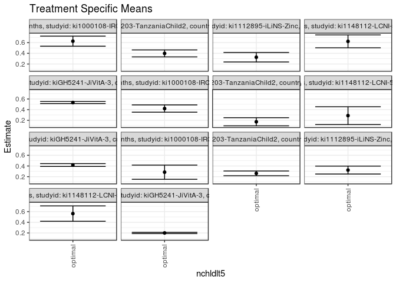

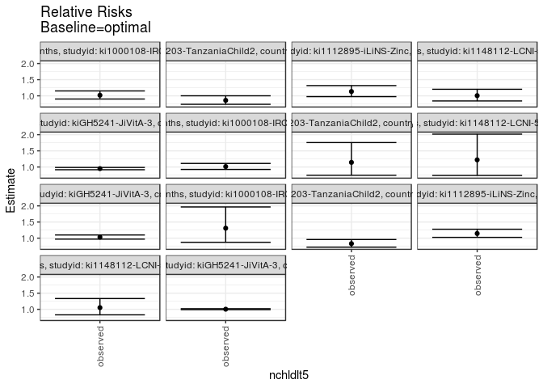

## Results Table

### Parameter: TSM

| agecat | studyid | country | intervention_level | baseline_level | estimate | ci_lower | ci_upper |
| --- | --- | --- | --- | --- | --- | --- | --- |
| 0-24 months | ki1000108-IRC | INDIA | optimal | NA | 0.6274092 | 0.5328523 | 0.7219661 |
| 0-24 months | ki1066203-TanzaniaChild2 | TANZANIA, UNITED REPUBLIC OF | optimal | NA | 0.3984717 | 0.3329886 | 0.4639548 |
| 0-24 months | ki1112895-iLiNS-Zinc | BURKINA FASO | optimal | NA | 0.3264469 | 0.2377854 | 0.4151083 |
| 0-24 months | ki1148112-LCNI-5 | MALAWI | optimal | NA | 0.6238088 | 0.5030408 | 0.7445769 |
| 0-24 months | kiGH5241-JiVitA-3 | BANGLADESH | optimal | NA | 0.5330519 | 0.5134459 | 0.5526579 |
| 0-6 months | ki1000108-IRC | INDIA | optimal | NA | 0.4206055 | 0.3522776 | 0.4889334 |
| 0-6 months | ki1066203-TanzaniaChild2 | TANZANIA, UNITED REPUBLIC OF | optimal | NA | 0.1728681 | 0.0966774 | 0.2490589 |
| 0-6 months | ki1148112-LCNI-5 | MALAWI | optimal | NA | 0.2880649 | 0.1212805 | 0.4548492 |
| 0-6 months | kiGH5241-JiVitA-3 | BANGLADESH | optimal | NA | 0.4178303 | 0.3914437 | 0.4442169 |
| 6-24 months | ki1000108-IRC | INDIA | optimal | NA | 0.2837103 | 0.1510625 | 0.4163581 |
| 6-24 months | ki1066203-TanzaniaChild2 | TANZANIA, UNITED REPUBLIC OF | optimal | NA | 0.2618449 | 0.2174500 | 0.3062398 |
| 6-24 months | ki1112895-iLiNS-Zinc | BURKINA FASO | optimal | NA | 0.3233822 | 0.2488995 | 0.3978649 |
| 6-24 months | ki1148112-LCNI-5 | MALAWI | optimal | NA | 0.5633176 | 0.4194694 | 0.7071657 |
| 6-24 months | kiGH5241-JiVitA-3 | BANGLADESH | optimal | NA | 0.2011201 | 0.1894290 | 0.2128112 |

### Parameter: E(Y)

| agecat | studyid | country | intervention_level | baseline_level | estimate | ci_lower | ci_upper |
| --- | --- | --- | --- | --- | --- | --- | --- |
| 0-24 months | ki1000108-IRC | INDIA | observed | NA | 0.6391753 | 0.5839030 | 0.6944475 |
| 0-24 months | ki1066203-TanzaniaChild2 | TANZANIA, UNITED REPUBLIC OF | observed | NA | 0.3426573 | 0.3201957 | 0.3651190 |
| 0-24 months | ki1112895-iLiNS-Zinc | BURKINA FASO | observed | NA | 0.3700418 | 0.3180183 | 0.4220652 |
| 0-24 months | ki1148112-LCNI-5 | MALAWI | observed | NA | 0.6277533 | 0.5832380 | 0.6722686 |
| 0-24 months | kiGH5241-JiVitA-3 | BANGLADESH | observed | NA | 0.5063144 | 0.4970144 | 0.5156143 |
| 0-6 months | ki1000108-IRC | INDIA | observed | NA | 0.4261168 | 0.3692020 | 0.4830316 |
| 0-6 months | ki1066203-TanzaniaChild2 | TANZANIA, UNITED REPUBLIC OF | observed | NA | 0.1975524 | 0.1787088 | 0.2163961 |
| 0-6 months | ki1148112-LCNI-5 | MALAWI | observed | NA | 0.3517241 | 0.2737325 | 0.4297157 |
| 0-6 months | kiGH5241-JiVitA-3 | BANGLADESH | observed | NA | 0.4314521 | 0.4224311 | 0.4404731 |
| 6-24 months | ki1000108-IRC | INDIA | observed | NA | 0.3712575 | 0.2977607 | 0.4447542 |
| 6-24 months | ki1066203-TanzaniaChild2 | TANZANIA, UNITED REPUBLIC OF | observed | NA | 0.2174672 | 0.1935626 | 0.2413719 |
| 6-24 months | ki1112895-iLiNS-Zinc | BURKINA FASO | observed | NA | 0.3700418 | 0.3180183 | 0.4220652 |
| 6-24 months | ki1148112-LCNI-5 | MALAWI | observed | NA | 0.5924051 | 0.5438847 | 0.6409254 |
| 6-24 months | kiGH5241-JiVitA-3 | BANGLADESH | observed | NA | 0.2019400 | 0.1906597 | 0.2132204 |

### Parameter: RR

| agecat | studyid | country | intervention_level | baseline_level | estimate | ci_lower | ci_upper |
| --- | --- | --- | --- | --- | --- | --- | --- |
| 0-24 months | ki1000108-IRC | INDIA | observed | optimal | 1.0187534 | 0.9014066 | 1.1513765 |
| 0-24 months | ki1066203-TanzaniaChild2 | TANZANIA, UNITED REPUBLIC OF | observed | optimal | 0.8599290 | 0.7383817 | 1.0014846 |
| 0-24 months | ki1112895-iLiNS-Zinc | BURKINA FASO | observed | optimal | 1.1335435 | 0.9756600 | 1.3169761 |
| 0-24 months | ki1148112-LCNI-5 | MALAWI | observed | optimal | 1.0063232 | 0.8418213 | 1.2029708 |
| 0-24 months | kiGH5241-JiVitA-3 | BANGLADESH | observed | optimal | 0.9498407 | 0.9157431 | 0.9852078 |
| 0-6 months | ki1000108-IRC | INDIA | observed | optimal | 1.0131033 | 0.9247167 | 1.1099381 |
| 0-6 months | ki1066203-TanzaniaChild2 | TANZANIA, UNITED REPUBLIC OF | observed | optimal | 1.1427928 | 0.7433311 | 1.7569228 |
| 0-6 months | ki1148112-LCNI-5 | MALAWI | observed | optimal | 1.2209894 | 0.7389667 | 2.0174320 |
| 0-6 months | kiGH5241-JiVitA-3 | BANGLADESH | observed | optimal | 1.0326012 | 0.9701827 | 1.0990355 |
| 6-24 months | ki1000108-IRC | INDIA | observed | optimal | 1.3085796 | 0.8705317 | 1.9670513 |
| 6-24 months | ki1066203-TanzaniaChild2 | TANZANIA, UNITED REPUBLIC OF | observed | optimal | 0.8305193 | 0.7197357 | 0.9583550 |
| 6-24 months | ki1112895-iLiNS-Zinc | BURKINA FASO | observed | optimal | 1.1442860 | 1.0254880 | 1.2768462 |
| 6-24 months | ki1148112-LCNI-5 | MALAWI | observed | optimal | 1.0516361 | 0.8292394 | 1.3336781 |
| 6-24 months | kiGH5241-JiVitA-3 | BANGLADESH | observed | optimal | 1.0040769 | 0.9897960 | 1.0185639 |

### Parameter: PAR

| agecat | studyid | country | intervention_level | baseline_level | estimate | ci_lower | ci_upper |
| --- | --- | --- | --- | --- | --- | --- | --- |
| 0-24 months | ki1000108-IRC | INDIA | optimal | NA | 0.0117660 | -0.0650096 | 0.0885417 |
| 0-24 months | ki1066203-TanzaniaChild2 | TANZANIA, UNITED REPUBLIC OF | optimal | NA | -0.0558143 | -0.1165532 | 0.0049246 |
| 0-24 months | ki1112895-iLiNS-Zinc | BURKINA FASO | optimal | NA | 0.0435949 | -0.0009774 | 0.0881671 |
| 0-24 months | ki1148112-LCNI-5 | MALAWI | optimal | NA | 0.0039445 | -0.1073935 | 0.1152824 |
| 0-24 months | kiGH5241-JiVitA-3 | BANGLADESH | optimal | NA | -0.0267375 | -0.0461135 | -0.0073616 |
| 0-6 months | ki1000108-IRC | INDIA | optimal | NA | 0.0055113 | -0.0328846 | 0.0439072 |
| 0-6 months | ki1066203-TanzaniaChild2 | TANZANIA, UNITED REPUBLIC OF | optimal | NA | 0.0246843 | -0.0496964 | 0.0990650 |
| 0-6 months | ki1148112-LCNI-5 | MALAWI | optimal | NA | 0.0636593 | -0.0795301 | 0.2068487 |
| 0-6 months | kiGH5241-JiVitA-3 | BANGLADESH | optimal | NA | 0.0136218 | -0.0124691 | 0.0397126 |
| 6-24 months | ki1000108-IRC | INDIA | optimal | NA | 0.0875472 | -0.0279641 | 0.2030585 |
| 6-24 months | ki1066203-TanzaniaChild2 | TANZANIA, UNITED REPUBLIC OF | optimal | NA | -0.0443777 | -0.0815874 | -0.0071679 |
| 6-24 months | ki1112895-iLiNS-Zinc | BURKINA FASO | optimal | NA | 0.0466595 | 0.0153775 | 0.0779416 |
| 6-24 months | ki1148112-LCNI-5 | MALAWI | optimal | NA | 0.0290875 | -0.1046488 | 0.1628238 |
| 6-24 months | kiGH5241-JiVitA-3 | BANGLADESH | optimal | NA | 0.0008200 | -0.0020599 | 0.0036998 |

### Parameter: PAF

| agecat | studyid | country | intervention_level | baseline_level | estimate | ci_lower | ci_upper |
| --- | --- | --- | --- | --- | --- | --- | --- |
| 0-24 months | ki1000108-IRC | INDIA | optimal | NA | 0.0184082 | -0.1093772 | 0.1314744 |
| 0-24 months | ki1066203-TanzaniaChild2 | TANZANIA, UNITED REPUBLIC OF | optimal | NA | -0.1628867 | -0.3543130 | 0.0014824 |
| 0-24 months | ki1112895-iLiNS-Zinc | BURKINA FASO | optimal | NA | 0.1178107 | -0.0249472 | 0.2406848 |
| 0-24 months | ki1148112-LCNI-5 | MALAWI | optimal | NA | 0.0062835 | -0.1879005 | 0.1687246 |
| 0-24 months | kiGH5241-JiVitA-3 | BANGLADESH | optimal | NA | -0.0528082 | -0.0920093 | -0.0150143 |
| 0-6 months | ki1000108-IRC | INDIA | optimal | NA | 0.0129339 | -0.0814123 | 0.0990489 |
| 0-6 months | ki1066203-TanzaniaChild2 | TANZANIA, UNITED REPUBLIC OF | optimal | NA | 0.1249507 | -0.3452956 | 0.4308230 |
| 0-6 months | ki1148112-LCNI-5 | MALAWI | optimal | NA | 0.1809921 | -0.3532409 | 0.5043203 |
| 0-6 months | kiGH5241-JiVitA-3 | BANGLADESH | optimal | NA | 0.0315719 | -0.0307337 | 0.0901113 |
| 6-24 months | ki1000108-IRC | INDIA | optimal | NA | 0.2358126 | -0.1487232 | 0.4916249 |
| 6-24 months | ki1066203-TanzaniaChild2 | TANZANIA, UNITED REPUBLIC OF | optimal | NA | -0.2040660 | -0.3893990 | -0.0434546 |
| 6-24 months | ki1112895-iLiNS-Zinc | BURKINA FASO | optimal | NA | 0.1260926 | 0.0248545 | 0.2168203 |
| 6-24 months | ki1148112-LCNI-5 | MALAWI | optimal | NA | 0.0491007 | -0.2059243 | 0.2501939 |
| 6-24 months | kiGH5241-JiVitA-3 | BANGLADESH | optimal | NA | 0.0040604 | -0.0103092 | 0.0182255 |